# Assignement2_DS

Yassine Lahbabi

27/04/2020

```r
# To clear everything in the WorkSpace.
rm(list = ls())
```

# 1 Assignement 2 : Data Statistics

My answers to Assignment 2 for Data Statistics are found below.

## 1.1 Question 1: Clustering

### 1.1.1 .a : Exploring the Dataset

In 1.a, we need to explore the dataset and summarise the variables that we have, and include any plots that we need for our study :

```r
pottery.complete <- read.csv("pottery.csv")

# Looking at the Top 6 values to make sure that the dataset has been read correctly.
head(pottery.complete)
```

```
##         kiln Al2O3 Fe2O3  MgO  CaO Na2O  K2O TiO2   MnO   BaO
## 1 Gloucester  18.8  9.52 2.00 0.79 0.40 3.20 1.01 0.077 0.015
## 2 Gloucester  16.9  7.33 1.65 0.84 0.40 3.05 0.99 0.067 0.018
## 3 Gloucester  18.2  7.64 1.82 0.77 0.40 3.07 0.98 0.087 0.014
## 4 Gloucester  17.4  7.48 1.71 1.01 0.40 3.16 0.03 0.084 0.017
## 5 Gloucester  16.9  7.29 1.56 0.76 0.40 3.05 1.00 0.063 0.019
## 6 Gloucester  17.8  7.24 1.83 0.92 0.43 3.12 0.93 0.061 0.019
```

```r
# Looking at the different structures of the variables in our dataset.
str(pottery.complete)
```

```
## 'data.frame':    48 obs. of  10 variables:
##  $ kiln : Factor w/ 5 levels "Ashley Rails",..: 3 3 3 3 3 3 3 3 3 3 ...
##  $ Al2O3: num  18.8 16.9 18.2 17.4 16.9 17.8 18.8 16.5 18 15.8 ...
##  $ Fe2O3: num  9.52 7.33 7.64 7.48 7.29 7.24 7.45 7.05 7.42 7.15 ...
##  $ MgO  : num  2 1.65 1.82 1.71 1.56 1.83 2.06 1.81 2.06 1.62 ...
##  $ CaO  : num  0.79 0.84 0.77 1.01 0.76 0.92 0.87 1.73 1 0.71 ...
##  $ Na2O : num  0.4 0.4 0.4 0.4 0.4 0.43 0.25 0.33 0.28 0.38 ...
##  $ K2O  : num  3.2 3.05 3.07 3.16 3.05 3.12 3.26 3.2 3.37 3.25 ...
##  $ TiO2 : num  1.01 0.99 0.98 0.03 1 0.93 0.98 0.95 0.96 0.93 ...
##  $ MnO  : num  0.077 0.067 0.087 0.084 0.063 0.061 0.072 0.066 0.072 0.062 ...
##  $ BaO  : num  0.015 0.018 0.014 0.017 0.019 0.019 0.017 0.019 0.017 0.017 ...
```

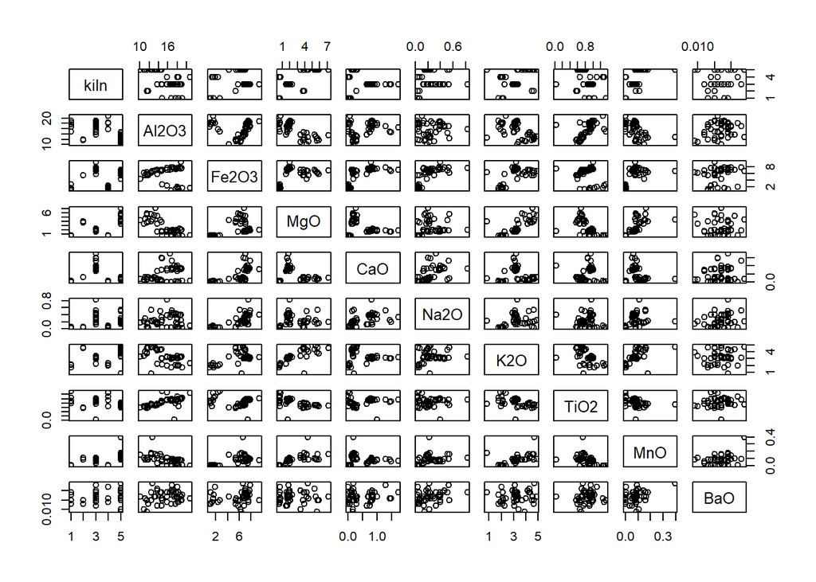

```r
# Plotting the pottery dataset (Since our variables may not be related we will not compare them between themselves).
plot(pottery.complete)
```

### 1.1.2 .b : Adjusting the Dataset

In 1.b, we need to remove the column ‘kiln’.

```r
# Removing the kiln column :
pottery = pottery.complete[c(-1)]
# Checking out if the kiln column has been removed.
str(pottery)
```

```
## 'data.frame':    48 obs. of  9 variables:
##  $ Al2O3: num  18.8 16.9 18.2 17.4 16.9 17.8 18.8 16.5 18 15.8 ...
##  $ Fe2O3: num  9.52 7.33 7.64 7.48 7.29 7.24 7.45 7.05 7.42 7.15 ...
##  $ MgO  : num  2 1.65 1.82 1.71 1.56 1.83 2.06 1.81 2.06 1.62 ...
##  $ CaO  : num  0.79 0.84 0.77 1.01 0.76 0.92 0.87 1.73 1 0.71 ...
##  $ Na2O : num  0.4 0.4 0.4 0.4 0.4 0.43 0.25 0.33 0.28 0.38 ...
##  $ K2O  : num  3.2 3.05 3.07 3.16 3.05 3.12 3.26 3.2 3.37 3.25 ...
##  $ TiO2 : num  1.01 0.99 0.98 0.03 1 0.93 0.98 0.95 0.96 0.93 ...
##  $ MnO  : num  0.077 0.067 0.087 0.084 0.063 0.061 0.072 0.066 0.072 0.062 ...
##  $ BaO  : num  0.015 0.018 0.014 0.017 0.019 0.019 0.017 0.019 0.017 0.017 ...
```

We will now standardize the data because it will make our dataset have the same scale, so our data becomes internally consistent because it will allow us to have the same content and format.

```r
scale.pottery = scale(pottery)

# Checking out the structure and the values again.
head(scale.pottery)
```

```
##          Al2O3     Fe2O3        MgO       CaO      Na2O         K2O       TiO2
## [1,] 1.1787012 1.5744454 -0.3148639 0.6196585 0.8884038  0.02101780  0.7323502
## [2,] 0.4756433 0.6410724 -0.5176903 0.7308080 0.8884038 -0.14170065  0.6388587
## [3,] 0.9566829 0.7731937 -0.4191746 0.5751987 0.8884038 -0.12000486  0.5921129
## [4,] 0.6606585 0.7050021 -0.4829200 1.1087164 0.8884038 -0.02237379 -3.8487339
## [5,] 0.4756433 0.6240245 -0.5698457 0.5529688 0.8884038 -0.14170065  0.6856044
## [6,] 0.8086707 0.6027146 -0.4133796 0.9086472 1.0608164 -0.06576537  0.3583841
##              MnO         BaO
## [1,] -0.04129390 -0.55791357
## [2,] -0.19145353  0.41003287
## [3,]  0.10886573 -0.88056239
## [4,]  0.06381784  0.08738405
## [5,] -0.25151738  0.73268168
## [6,] -0.28154931  0.73268168
```

```r
str(scale.pottery)
```

```
##  num [1:48, 1:9] 1.179 0.476 0.957 0.661 0.476 ...
##  - attr(*, "dimnames")=List of 2
##   ..$ : NULL
##   ..$ : chr [1:9] "Al2O3" "Fe2O3" "MgO" "CaO" ...
##  - attr(*, "scaled:center")= Named num [1:9] 15.615 5.826 2.543 0.511 0.245 ...
##   ..- attr(*, "names")= chr [1:9] "Al2O3" "Fe2O3" "MgO" "CaO" ...
##  - attr(*, "scaled:scale")= Named num [1:9] 2.702 2.346 1.726 0.45 0.174 ...
##   ..- attr(*, "names")= chr [1:9] "Al2O3" "Fe2O3" "MgO" "CaO" ...
```

### 1.1.3 .c : Hierarchical Clustering and average linkage.

Now we will try to plot the Sum of square against the number of cluster, so we can find an elbow.

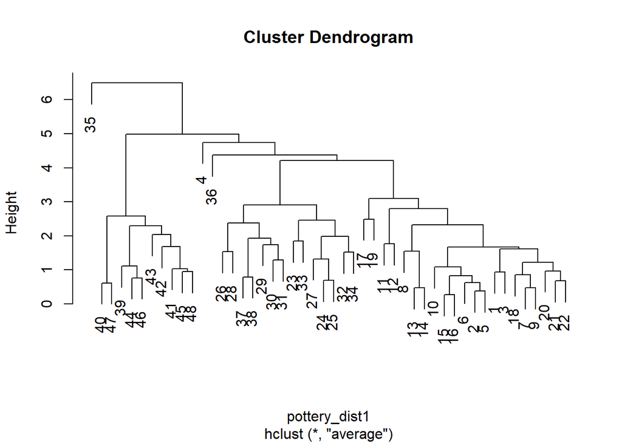

```r
pottery_dist1 <- dist(scale.pottery,method = "euclidean")
cl.average <- hclust(pottery_dist1,method = "average")
plot(cl.average)
```

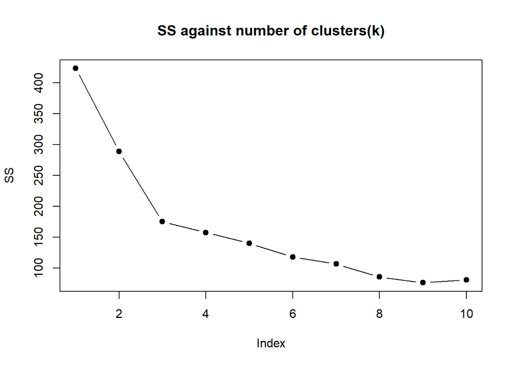

```r
SS <- rep(0,10)

n <- nrow(scale.pottery)
SS[1] <- (n-1)*sum(apply(scale.pottery,2,var))

set.seed(13)
for(k in 2:10){
  SS[k] <- sum(kmeans(scale.pottery,centers =k)$withinss)
}

plot(SS, main = "SS against number of clusters(k)",pch =19, type ="b")
```

```r
hierachical.cluster <- cutree(tree = cl.average,k=3)
hierachical.cluster
```

```
##  [1] 1 1 1 1 1 1 1 1 1 1 1 1 1 1 1 1 1 1 1 1 1 1 1 1 1 1 1 1 1 1 1 1 1 1 2 1 1 1
## [39] 3 3 3 3 3 3 3 3 3 3
```

```r
table(hierachical.cluster)
```

```
## hierachical.cluster
##  1  2  3
## 37  1 10
```

```r
table(hierachical.cluster,pottery.complete$kiln)
```

```
##
## hierachical.cluster Ashley Rails Caldicot Gloucester Islands Thorns Llanedeyrn
##                   1            0        2         22              0         13
##                   2            0        0          0              0          1
##                   3            5        0          0              5          0
```

In the last table, when we do a comparison between the real results and the results that we have just found, we can clearly notice that there is 5 groups instead of 3, and the hierarchical algorithm isn’t very accurate because it did not manage to cluster the whole group of values.

### 1.1.4 .d : K-Means Clustering

Let’s move on now to the K-means Clustering :

```r
library(ggplot2)
#install.packages("HSAUR2")
library(HSAUR2)

##########################################
# We're interested in how 'tightly packed' clusters are - this is the Within Group SS
# Let's find this for clustering solutions for k=1 up to k=10:
SS <- rep(0, 10)
SS
```

```
##  [1] 0 0 0 0 0 0 0 0 0 0
```

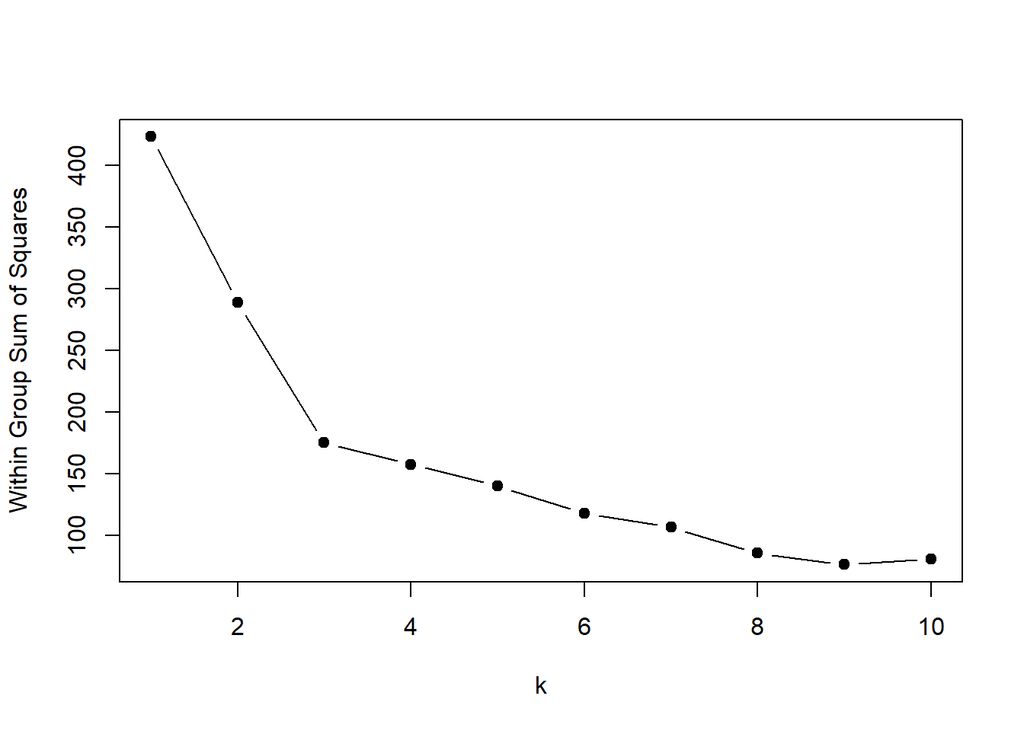

```r
# Finding the k = 1 solution separately, as kmeans() doesn't do this:
n <- nrow(scale.pottery)
SS[1] <- (n - 1) * sum(apply(scale.pottery, 2, var))

set.seed(13)
for(k in 2:10) {
  SS[k] <- sum(kmeans(scale.pottery, centers = k)$withinss)
}

# Let's plot k against the SS:
plot(1:10, SS,
     type = "b", xlab = "k",
     ylab = "Within Group Sum of Squares", pch = 19)
```

```r
# Seems to suggest 3 groups but we know they are 5 different locations
# Let's try with 3 and 5.
k <- 3
kcl1 <- kmeans(scale.pottery, center = k)
table(kcl1$cluster)
```

[output not shown]

```
##
##  1  2  3
## 10 22 16
```

```r
table(kcl1$cluster, pottery.complete$kiln)
```

```
##
##     Ashley Rails Caldicot Gloucester Islands Thorns Llanedeyrn
##   1            5        0          0              5          0
##   2            0        0         22              0          0
##   3            0        2          0              0         14
```

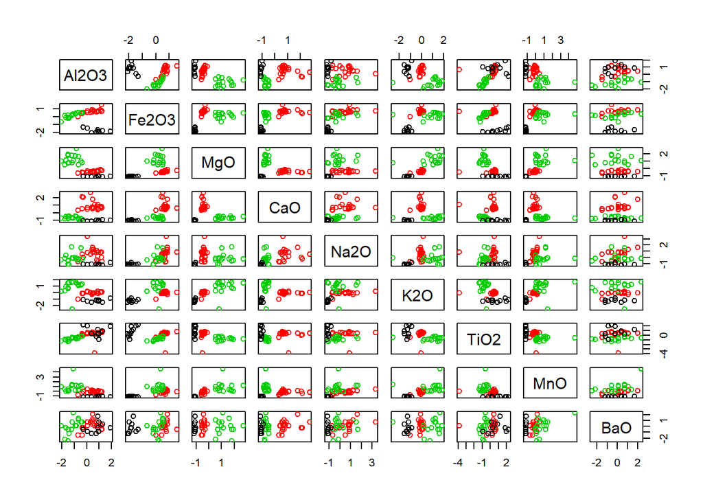

```r
# Visualising these:
pairs(scale.pottery, col = kcl1$cluster)
```

[figure not shown]

```r
pairs(scale.pottery, col = pottery$kiln)
```

At this time, 3 clusters would be an ideal solution for clustering the pottery data using K-means algorithm.